# COMPSCIX 415.2 Homework 6

Gregory Spathias

July 16, 2018

```r
library(tidyverse)
```

```r
library(mosaicData)
```

### **Exercise 1**

```r
data(Whickham)
```

#### **1.**

The variables in the dataset are: * outcome - survival status after 20 years: a factor with levels ‘Alive’ or ‘Dead’ * smoker - smoking status at baseline: a factor with levels ‘Yes’ or ‘No’ * age - age (in years) at the time of the first survey

#### **2.**

There are 1,314 observations in this dataset. They each represent women who were classified as current smokers or as never having smoked.

#### **3.**

```r
Whickham %>% count(smoker, outcome)
```

```
## # A tibble: 4 x 3
##   smoker outcome     n
##   <fct>  <fct>   <int>
## 1 No     Alive     502
## 2 No     Dead      230
## 3 Yes    Alive     443
## 4 Yes    Dead      139
```

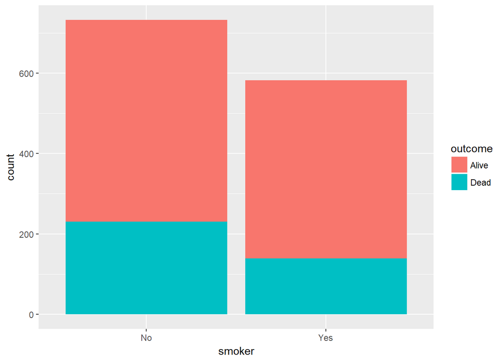

```r
Whickham %>% ggplot(aes(x = smoker)) + geom_bar(aes(fill = outcome))
```

#### **4.**

```r
Whickham_w_age_groups <- Whickham %>% mutate(age_group =
  case_when(age <= 44 ~ '<=44',
            age > 44 & age <= 64 ~ 'between 44 and 64',
            age > 64 ~ 'age >64'))
```

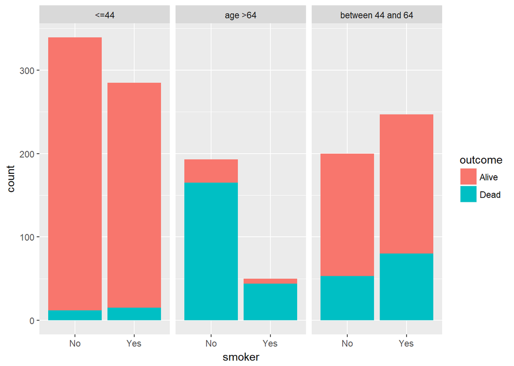

```r
Whickham_w_age_groups %>% ggplot(aes(x = smoker)) + geom_bar(aes(fill = outcome)) + facet_grid(~ age_group)
```

### **Exercise 2**

#### **1.**

```r
n <- 10000

# look at ?rgamma to read about this function
gamma_samp <- tibble(x = rgamma(n, shape = 1, scale = 2))
```

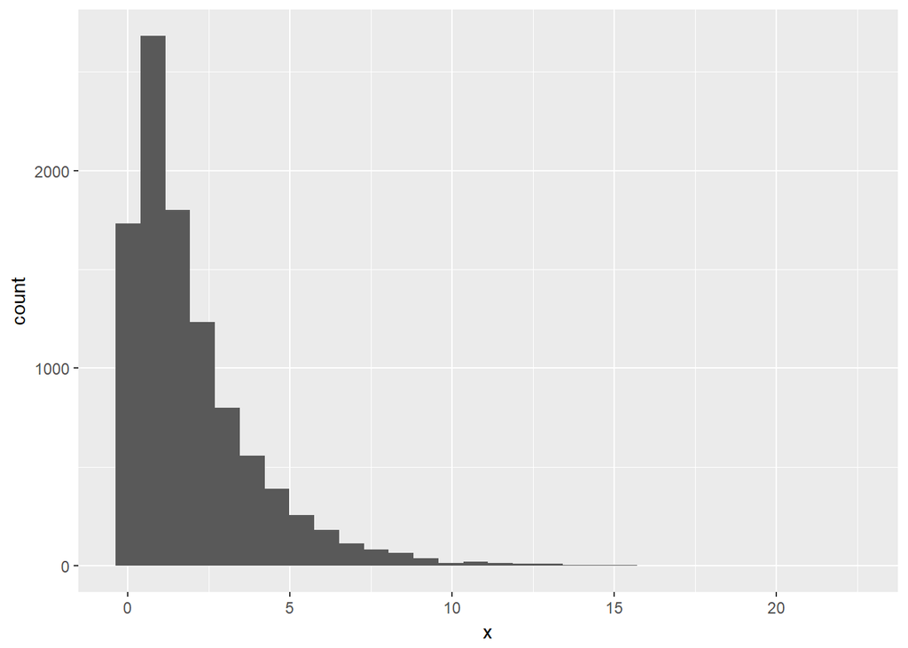

```r
gamma_samp %>% ggplot() + geom_histogram(mapping = aes(x =x))
```

#### **2.**

```r
gamma_samp %>% summarize( mean = mean(x, na.rm = TRUE), sd = sd(x, na.rm = TRUE))
```

```
## # A tibble: 1 x 2
##    mean    sd
##   <dbl> <dbl>
## 1  1.98  1.99
```

Both of these are close to 2.

#### **3.**

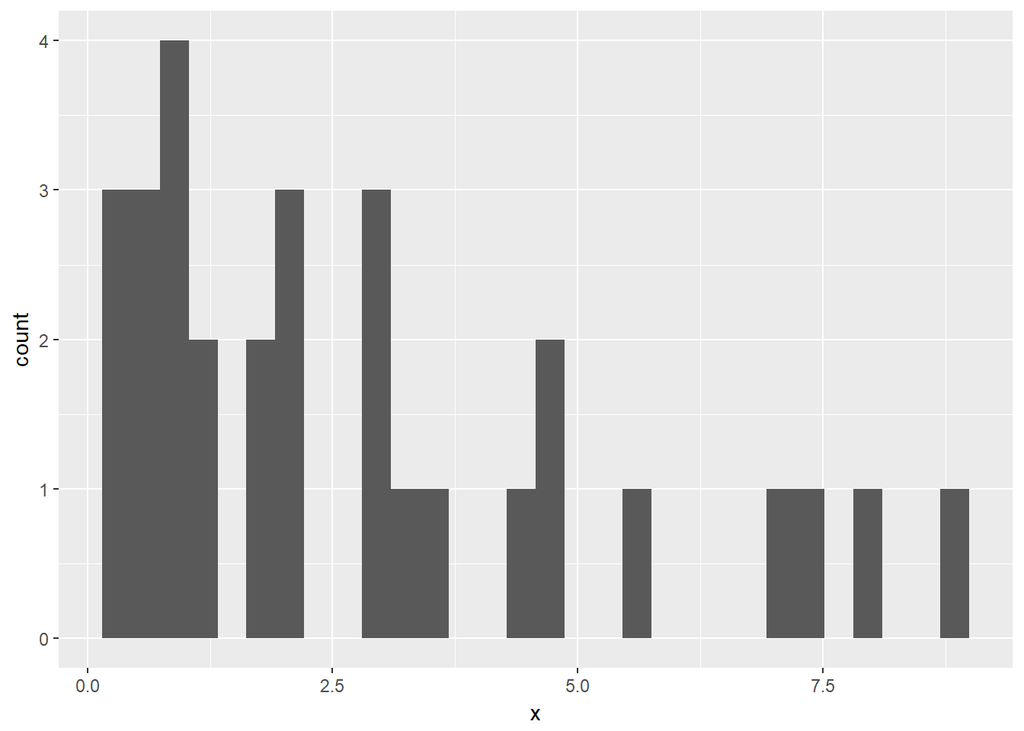

```r
n2 <- 30

# look at ?rgamma to read about this function
gamma_samp_2 <- tibble(x = rgamma(n2, shape = 1, scale = 2))
gamma_samp_2 %>% ggplot() + geom_histogram(mapping = aes(x =x))
```

```r
gamma_samp_2 %>% summarize( mean = mean(x, na.rm = TRUE), sd = sd(x, na.rm = TRUE))
```

```
## # A tibble: 1 x 2
##    mean    sd
##   <dbl> <dbl>
## 1  2.81  2.47
```

#### **4.**

```r
# create a vector with 10000 NAs
mean_samp <- rep(NA, 10000)

# start a loop
for(i in 1:10000) {
  g_samp <- rgamma(30, shape = 1, scale = 2)
  mean_samp[i] <- mean(g_samp)
}
# Convert vector to a tibble
mean_samp <- tibble(mean_samp)
```

#### **5.**

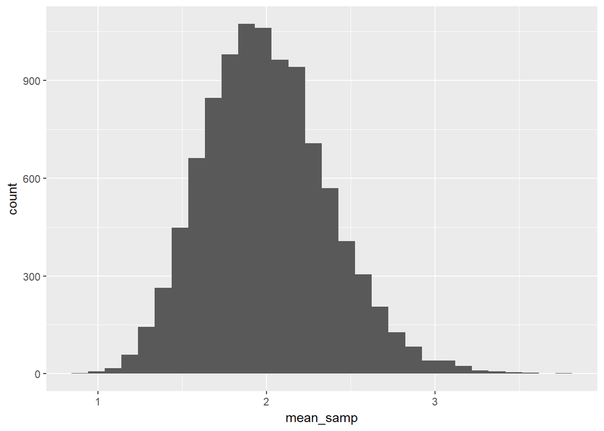

```r
mean_samp %>% ggplot() + geom_histogram(mapping = aes(x =mean_samp))
```

```r
mean_samp %>% summarize(mean = mean(mean_samp, na.rm = TRUE), sd = sd(mean_samp, na.rm = TRUE))
```

```
## # A tibble: 1 x 2
##    mean    sd
##   <dbl> <dbl>
## 1  2.00 0.370
```

#### **7.**

The standard deviation is much smaller than our gamma samples, but this Standard Deviation is much larger than I would imagine it to be. All of the means should be close to 2 so I would think the SD would be close to 0.

#### **8.**

```r
mean_samp <- rep(NA, 10000)

# start a loop
for(i in 1:10000) {
  g_samp <- rgamma(300, shape = 1, scale = 2)
  mean_samp[i] <- mean(g_samp)
}
# Convert vector to a tibble
mean_samp <- tibble(mean_samp)
```

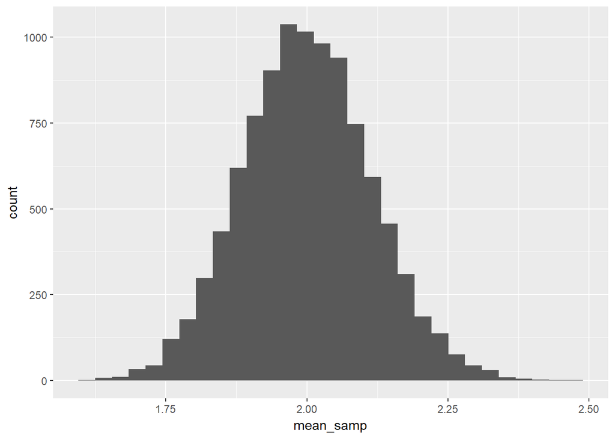

```r
mean_samp %>% ggplot() + geom_histogram(mapping = aes(x =mean_samp))
```

```r
mean_samp %>% summarize(mean = mean(mean_samp, na.rm = TRUE), sd = sd(mean_samp, na.rm = TRUE))
```

```
## # A tibble: 1 x 2
##    mean    sd
##   <dbl> <dbl>
## 1  2.00 0.115
```

```r
2/sqrt(300)
```

```
## [1] 0.1154701
```

Yes, this sample also matches up with the Central Limit Theorem as the SD should be close to 2 divided by the square root of 300 which is 0.1154701 and the SD is 0.1155744. The theorem checks out.